# pooled_01

Daniel Goodman & Kiavash Garakani

originally 2/9/2019, refreshed 4/4/2020

Primary questions addressed in this notebook:

- Data Quality
  - Impact of: CAR length, CAR abundance
- CAR Performance
  - CAR score measurement
  - Which CARs behave similarly?
    - Impact of CAR length
    - tSNE of CARs, plotted with proliferation, exhaustion, etc.
- Sample Correlations
  - tSNE of CAR scores
  - Correlation plots

Notebook Layout:

1. Data pre-processing and quality assessment.
2. CAR performance analysis.
3. Sample correlation analysis.

# Data Pre-Processing and Quality Assessment

```r
library(data.table)
library(ggplot2)
library(knitr)
```

### User Inputs

```r
tcsl.dir <- here::here(
  '..','..',
  's3-roybal-tcsl',
  'lenti_screen_compiled_data','data','ngs')

dataset.name <- '2019.01.31.illumina_06'
data.dir <- file.path(tcsl.dir, dataset.name, 'uniq')
output.dir <- file.path(here::here('..','figs','pooled'))
data.output.dir <- file.path(here::here(
  '..','..',
  's3-roybal-tcsl',
  'lenti_screen_compiled_data','data'))
metadata.filename <- file.path(tcsl.dir,
    dataset.name, paste0(dataset.name, '_layout.csv'))
car.seq.filename <- file.path(tcsl.dir, dataset.name, 'fa/ref.csv')
remove.cars <- c('*','41BB.wt','CD28.wt','ICOS.wt','TIIM1')


car.seq <- fread(car.seq.filename, header=F)
names(car.seq) <- c('CAR.align','seq')
car.seq[, len := nchar(seq)]
car.len <- car.seq[, list(CAR.align, len)]

# global options
opts_knit$set(fig_dim= c(10,10))
theme_set(theme_bw())

# exponent base for calculating car scores from bin percents
car.score.base.exp <- 2
```

### Load and Preprocess Data

```r
# store filenames
read.count.filenames <- list.files(data.dir, pattern="*.ref_counts.csv")
bad.pair.filenames <- list.files(data.dir, pattern="*.bad_read_pairs.csv")

# initialize read.counts
read.counts <- fread(file.path(data.dir, read.count.filenames[1]),
  col.names=c("CAR.align", "V1"))[order(CAR.align), "CAR.align"]

# load and merge data to read.counts
for (file in read.count.filenames){
  sample.num <- strsplit(file, "_")[[1]][1]
  counts <- fread(file.path(data.dir, file), col.names=c("CAR.align", sample.num))
  read.counts <- merge(read.counts, counts, by="CAR.align")
}

# load metadata
metadata <- fread(metadata.filename, header=T)[is.na(sample.num) == F]

# call donors d#
metadata[, donor := paste0('d', donor)]

# melt sample and counts
read.counts <- melt.data.table(
    read.counts,
    id.vars=c('CAR.align'),
    variable.name = 'sample.num',
    value.name='counts')

# merge read.counts with metadata
read.counts <- read.counts[metadata[,
                  sample.num := as.factor(sample.num)], on='sample.num']
# read.counts <- read.counts[!(CAR.align %in% remove.cars)]

# make sort group
read.counts[, sort.group := paste(batch, donor, timepoint, assay, t.type, k.type, sep='_')]
rm("counts", "file", "sample.num")

# add car lengths
read.counts <- read.counts[car.len, on='CAR.align']

# map back to actual names from costim table - we want to rename some
# use correct names, from costim table
csv.dir <- here::here(
  '..','..',
  's3-roybal-tcsl',
  'lenti_screen_compiled_data','data','csv')

# names of domains to map onto actual car names
domain_names <- fread(file.path(csv.dir, 'costim_table.csv'), fill=T)[,
  list(CAR.orig=r_name, CAR.new=real_name)]

read.counts <- merge(read.counts, domain_names,
  by.x='CAR.align', by.y='CAR.orig', all=T)

#rename CARs, save old name as CAR.orig
read.counts[, CAR.orig := CAR.align]
read.counts[, CAR.align := CAR.new]
```

### Data Quality Analysis

```r
read.counts <- read.counts[!(CAR.orig %in% remove.cars)]

# if pct is available
read.counts[, cell.count := as.numeric(gsub(',','',cell.count))][!is.na(pct), bin.pct :=
                pct/sum(pct), by = .(CAR.align, sort.group)]
# if not, use cell counts
read.counts[is.na(pct), bin.pct := cell.count/sum(cell.count), by = .(CAR.align, sort.group)]

total.bin.pct.plot <- ggplot(read.counts[!(CAR.align %in% remove.cars),
                                         list(bin.pct=bin.pct[1]),
                                         by=.(batch, donor, timepoint,
                                              assay, t.type, k.type, bin)]) +
  geom_bar(aes(y=bin.pct, x=bin), stat='identity') +
  facet_grid(k.type~batch+timepoint+assay+t.type+donor) +
  labs(title='Total Bin Percentages')

nonaligning.reads.plot <- ggplot(read.counts[,
    sum(counts[CAR.align == '*'])/sum(counts),
    by=.(batch, donor, timepoint, assay, t.type, k.type, bin)]) +
  geom_bar(aes(y=V1, x=bin), stat='identity') +
  facet_grid(k.type~batch+donor+timepoint+assay+t.type) +
  labs(title='percentage of non-aligning reads')

# ggplot(read.counts[,
#         list(CAR_align=CAR_align[CAR_align %in% remove_cars],
#              pct=counts[CAR_align %in% remove_cars]/sum(counts)),
#         by=c('sample_name','sample_num','sort_group','Bin')]) +
#     geom_bar(aes(y=pct, x=Bin, fill=CAR_align),
#         stat='identity', position='dodge') +
#     facet_wrap(~sort_group) +
#     labs(title='percentages of contaminationg & nonaligning reads')
#
# ggplot(read.counts[,
#         list(counts=sum(counts[!(CAR_align %in% remove_cars)])),
#         by=c('sample_name','sample_num','sort_group','Bin')]) +
#     geom_bar(aes(y=counts, x=Bin), stat='identity') +
#     facet_wrap(~sort_group) +
#     labs(title='number of aligning reads')
#
# ggplot(read.counts[,
#         list(counts=sum(counts[!(CAR_align %in% remove_cars)])),
#         by=c('sample_name','sample_num','sort_group','Bin')]) +
#     geom_bar(aes(y=counts, x=Bin), stat='identity') +
#     facet_wrap(~sort_group) + scale_y_log10() +
#     labs(title='log10 - number of aligning reads')

ggsave(paste0(output.dir,'/total_bin_percentages.png'),
       total.bin.pct.plot,
       width = 60,
       height = 20,
       units = 'cm',
       dpi = 1000)
ggsave(paste0(output.dir,'/nonaligning_reads_percentages.png'),
       nonaligning.reads.plot,
       width = 60,
       height = 20,
       units = 'cm',
       dpi = 1000)
```

On using `cell.count` vs `pct`: let’s use the bin percent recorded if it is available, else let’s use the cell count. Sometimes if a bin fills up we stop sorting into it, so the cell counts will not accurately reflect the bin percents.

# Removing CD96 from Prolif1 D2

CD96 bin C is overwhelming the rest of the CARs for Prolif1 CTV3 D2. We will remove that CAR from that sort group before calculating CAR scoring; he likely became overamplified for some reason.

```r
read.counts <- read.counts[(sort.group != 'prolif1_d2_24d_CTV3_CD4_pos') |
  (sort.group == 'prolif1_d2_24d_CTV3_CD4_pos' & CAR.align != 'CD96')]
```

# CAR performance analysis

### Calculate bin percentage estimates

`car.abs.pct` : Absolute Percent of Reads in whole sort for a CAR
$$\displaystyle \text{car.abs.pct}_{car, bin} = \text{car.bin.read.pct}_{car, bin} \times \text{bin.pct}_{bin}$$

`car.abund` : CAR percentage in the library for this sort
$$\displaystyle \text{car.abund}_{car} = \sum_{bin}\text{car.abs.pct}_{car}$$

`car.bin.pct` : Estimate of ‘Real’ Percentage of the CAR per bin
$$\displaystyle \text{car.bin.pct}_{car, bin} = \text{car.abs.pct}_{car, bin} / \text{car.abund}_{car}$$

```r
# get bin percent estimates
read.counts[, bin.reads := sum(counts, na.rm=T), by=c('sort.group','bin')]

read.counts[, car.bin.read.pct := counts/bin.reads, by=c('sort.group','bin')]

# car bin read pcts should sum to 1
read.counts[, stopifnot(all.equal(sum(car.bin.read.pct), 1)), by=c('sort.group','bin')]
```

```
## Empty data.table (0 rows and 2 cols): sort.group,bin
```

```r
# bin pcts should sum to 1
read.counts[, stopifnot(all.equal(sum(bin.pct), 1)),
            by=c('sort.group','CAR.align')]
```

```
## Empty data.table (0 rows and 2 cols): sort.group,CAR.align
```

```r
# get car absolute pct estimates
read.counts[, car.abs.pct := car.bin.read.pct*(bin.pct), by='sort.group']

# absolute pct estimates should sum to 1
read.counts[, stopifnot(all.equal(sum(car.abs.pct), 1)), by=c('sort.group')]
```

```
## Empty data.table (0 rows and 1 cols): sort.group
```

```r
# get car abund
read.counts[, car.abund := sum(car.abs.pct), by=c('sort.group','CAR.align')]

# CAR abundances should sum to 1
read.counts[, stopifnot(all.equal(sum(car.abund), 1)),
    by=c('sort.group','bin')]
```

```
## Empty data.table (0 rows and 2 cols): sort.group,bin
```

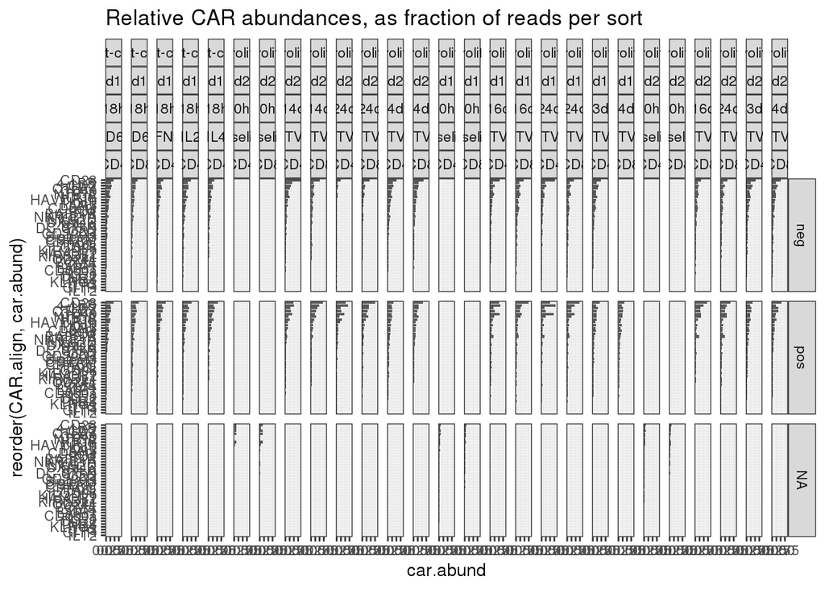

```r
read.counts[, car.bin.pct := car.abs.pct/car.abund]

# other metrics
read.counts[, rel.car.pct := (bin.pct - mean(bin.pct)) / mean(bin.pct),
    by=c('sort.group','CAR.align')]
read.counts[, mean.bin.pct := mean(bin.pct),
    by=c('sort.group','CAR.align')]
read.counts[, sort.reads := sum(counts),
    by=c('sort.group','CAR.align')]
read.counts[, mean.car.abund := mean(car.abund), by=c('CAR.align')]
read.counts[, rel.car.abund := car.abund/mean(car.abund), by='CAR.align']

min.sort.reads <- 100

ggplot(read.counts[sort.reads > min.sort.reads]) +
    geom_bar(
        aes(
            y=car.abund,
            x=reorder(CAR.align,car.abund)),
        stat='identity') +
    facet_grid(k.type ~ batch+donor+timepoint+assay+t.type) + coord_flip() +
    labs(title='Relative CAR abundances, as fraction of reads per sort')
```

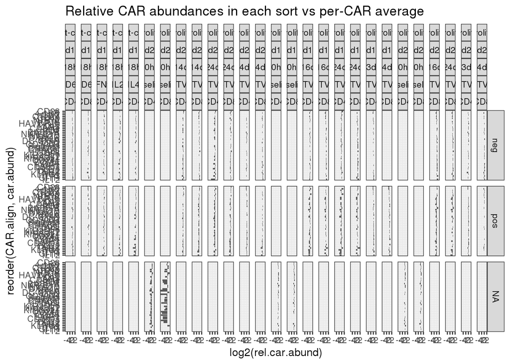

```r
ggplot(read.counts[sort.reads > min.sort.reads]) +
    geom_bar(
        aes(
            y=log2(rel.car.abund),
            x=reorder(CAR.align,car.abund)),
        stat='identity', position='dodge') +
    labs(title='Relative CAR abundances in each sort vs per-CAR average') +
    facet_grid(k.type ~ batch+donor+timepoint+assay+t.type) + coord_flip()
```

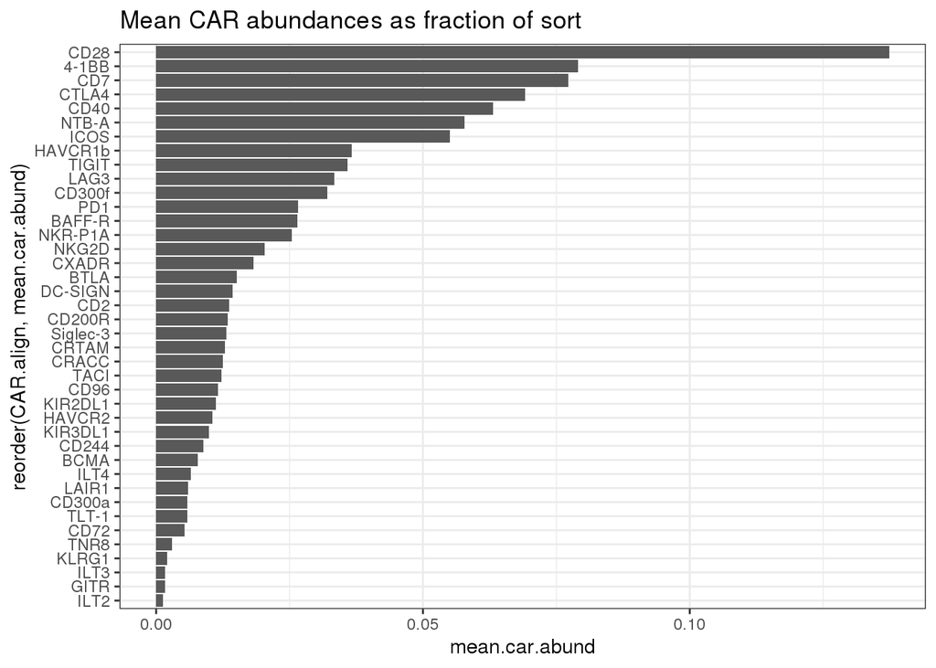

```r
ggplot(unique(read.counts[sort.reads > min.sort.reads,
                          mean.car.abund, by=CAR.align])) +
    geom_bar(
        aes(
            y=mean.car.abund,
            x=reorder(CAR.align,mean.car.abund)),
        stat='identity') +
    coord_flip() +
    labs(title='Mean CAR abundances as fraction of sort')
```

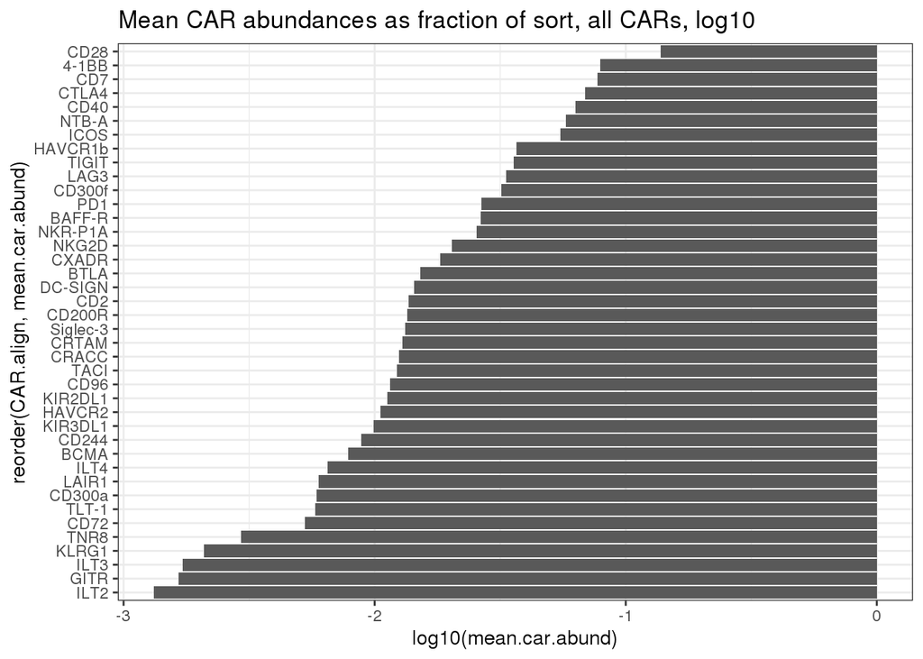

```r
ggplot(unique(read.counts[sort.reads > min.sort.reads,
                   mean.car.abund, by=CAR.align])) +
    geom_bar(
        aes(
            y=log10(mean.car.abund),
            x=reorder(CAR.align, mean.car.abund)),
        stat='identity') +
    coord_flip() +
    labs(title='Mean CAR abundances as fraction of sort, all CARs, log10')
```

# CAR Scoring

To convert the bin percentages to a single score, each bin will get a relative score:

For CD69, IL-2, IFNy, and IL-4:

$$\text{car.score} = \sum_{\text{bin}=A,B,C,D} \text{car.score.base.exp}^{\text{bin.score}_{bin}} \times \text{bin.pct}_{bin}$$

These `bin.pct` scores are reversed for CTV1, 2, and 3: $A=3, B=2, C=1, D=0$.

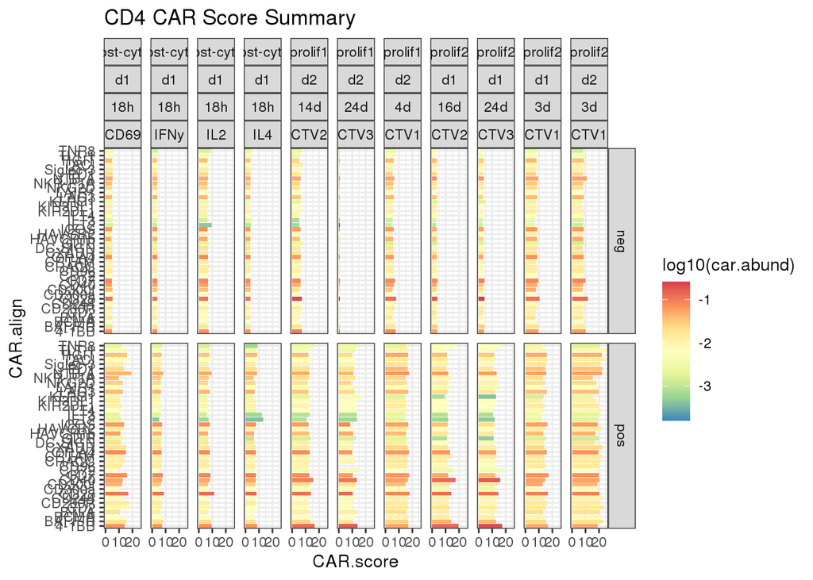

```r
# CAR score from bin percents
bin.score <- data.frame(
    bin=LETTERS[1:4],
    bin.score = car.score.base.exp^seq(0,3),
    ctv.bin.score = car.score.base.exp^seq(3,0))

read.counts <- merge(read.counts, bin.score, on='bin', all=T)

read.counts[, CAR.score := sum(car.bin.pct*bin.score), by=c('sort.group',
                                                            'CAR.align')]

read.counts[grep('CTV', sort.group),
            CAR.score := sum(car.bin.pct*ctv.bin.score),
            by=c('sort.group','CAR.align')]

cd4.car.score.plot <- ggplot(read.counts[t.type == "CD4" & k.type != "NA"]) +
  geom_bar(aes(x=CAR.align, y=CAR.score, fill=log10(car.abund)),
           stat='identity') +
  coord_flip() +
  facet_grid(k.type ~ batch+donor+timepoint+assay) +
  scale_fill_distiller(palette="Spectral") +
  labs(title='CD4 CAR Score Summary')

cd8.car.score.plot <- ggplot(read.counts[t.type == "CD8" & k.type != "NA"]) +
  geom_bar(aes(x=CAR.align, y=CAR.score, fill=log10(car.abund)),
           stat='identity') +
  coord_flip() +
  facet_grid(k.type ~ batch+donor+timepoint+assay) +
  scale_fill_distiller(palette = "Spectral") +
  labs(title='CD8 CAR Score Summary')

cd4.car.score.plot
```

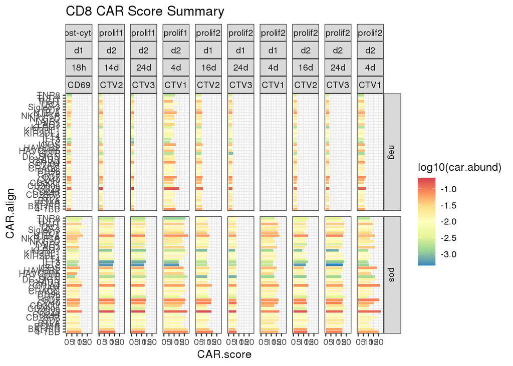

```r
cd8.car.score.plot
```

```r
ggsave(paste0(output.dir,'/cd4_car_score_plot.pdf'),
  cd4.car.score.plot,
  width = 12,
  height = 12,
  units = 'in')

ggsave(paste0(output.dir,'/cd8_car_score_plot.pdf'),
  cd8.car.score.plot,
  width = 12,
  height = 12,
  units = 'in')

save(list=c('read.counts'), file=file.path(data.output.dir, 'pooled_read_counts.Rdata'))
```

# Nicer Data Quality Analysis plots, copied from 02

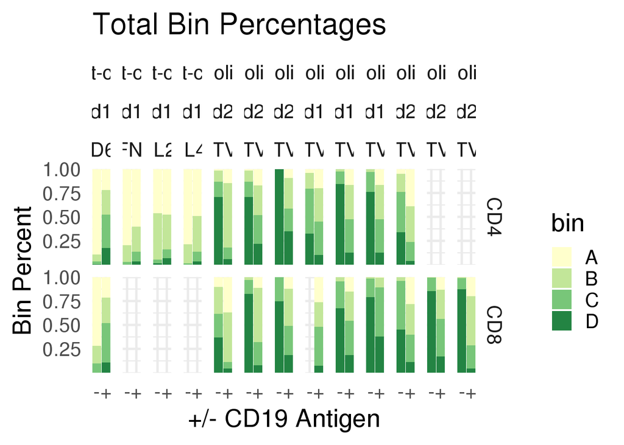

```r
library(knitr)
opts_knit$set(fig_dim= c(10,10))
theme_set(theme_minimal())


# convert to days
read.counts[grep('(\\d+)d', timepoint), day := as.numeric(gsub('(\\d+)d','\\1', timepoint))]
read.counts[grep('(\\d+)h', timepoint), day := as.numeric(gsub('(\\d+)h','\\1', timepoint)) / 24]

ggplot(read.counts[k.type != "NA",
    list(bin.pct=bin.pct[1]),
    by=.(batch, donor, timepoint,
        assay, t.type, k.type, bin)]) +
  geom_bar(aes(y=bin.pct, x=k.type, fill=bin), stat='identity', width=0.95) +
  scale_fill_brewer(palette = "YlGn") +
  facet_grid(t.type~batch+donor+assay, scales = 'free_x') +
  labs(title='Total Bin Percentages', y='Bin Percent') +
  theme(axis.title.x=element_blank()) +
  scale_x_discrete('+/- CD19 Antigen', expand = c(0, 0), labels=c('-','+')) +
  scale_y_continuous(limits = c(0,1), expand = expansion(mult = c(0, 0)),
                     breaks=c(0.25, 0.5, 0.75, 1)) +
  theme_minimal(base_size=20)
```

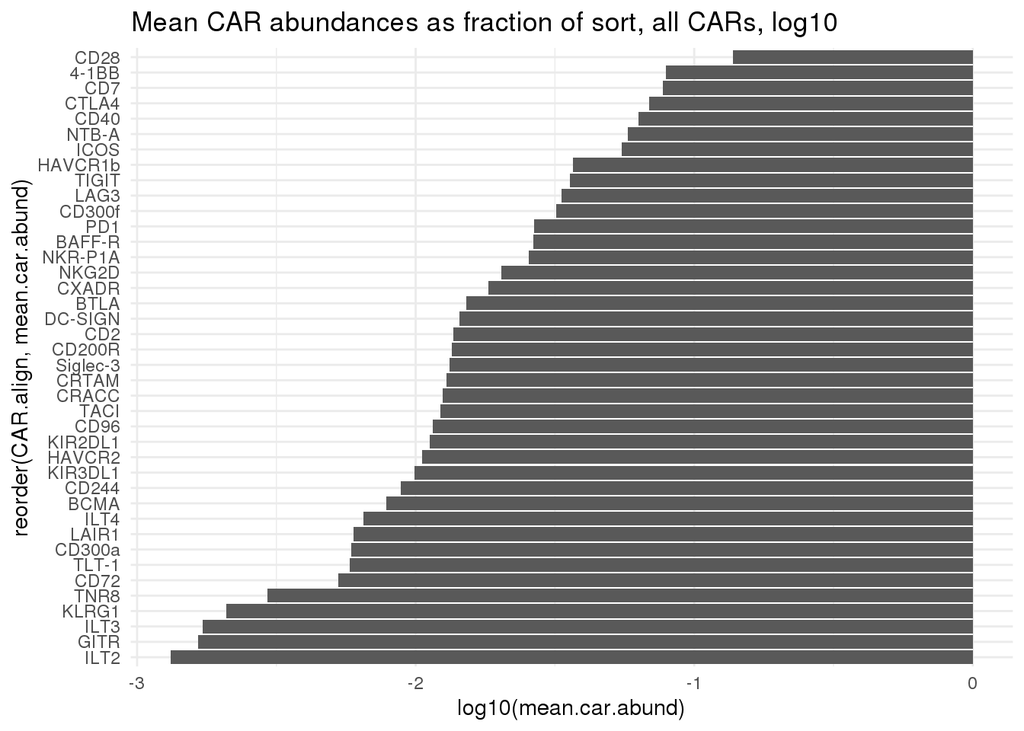

```r
ggplot(unique(read.counts[sort.reads > min.sort.reads,
                          mean.car.abund, by=CAR.align])) +
  geom_bar(aes(y=log10(mean.car.abund),
               x=reorder(CAR.align, mean.car.abund)),
           stat='identity') +
  coord_flip() +
  labs(title='Mean CAR abundances as fraction of sort, all CARs, log10')
```

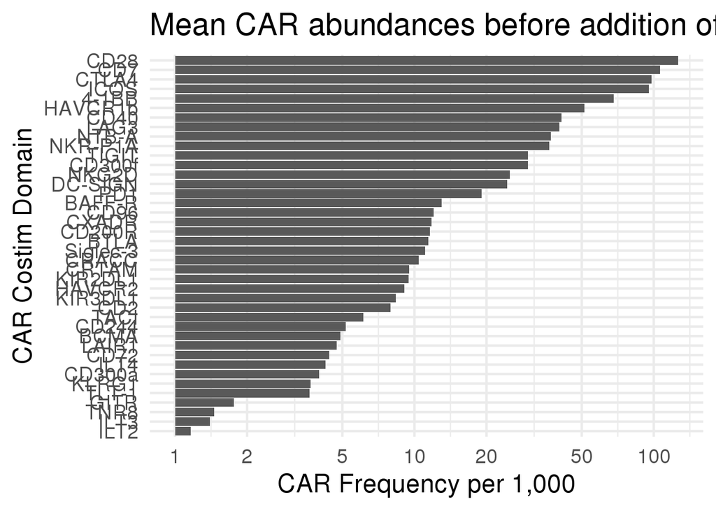

```r
ggplot(read.counts[sort.reads > min.sort.reads, mean(car.abund[assay=='baseline']),
                   by=CAR.align]) +
  geom_bar(aes(y=1000*V1,
               x=reorder(CAR.align,V1)),
           stat='identity') +
  scale_y_log10('CAR Frequency per 1,000', breaks=c(1,2,5,10,20,50,100)) +
  theme_minimal(base_size=18) +
  coord_flip() +
  scale_x_discrete('CAR Costim Domain') +
  labs(title='Mean CAR abundances before addition of K562s')
```

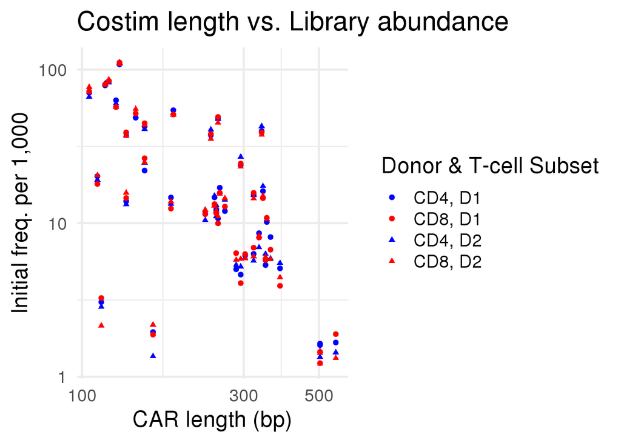

```r
# (Insert why we switched baselines for one of them)

ggplot(read.counts[assay == 'baseline' & batch == 'prolif2']) +
  geom_point(aes(x=len, y=car.abund*1000, color=interaction(donor, t.type),
                 shape=interaction(donor, t.type), label=CAR.align)) +
  scale_x_log10() + scale_y_log10() +
  labs(title='Costim length vs. Library abundance',
       x='CAR length (bp)', y='Initial freq. per 1,000') +
  scale_colour_manual(name = "Donor & T-cell Subset",
                      labels = c("CD4, D1", "CD8, D1", "CD4, D2", "CD8, D2"),
                      values = c("blue", "red", "blue", "red")) +
  scale_shape_manual(name = "Donor & T-cell Subset",
                      labels = c("CD4, D1", "CD8, D1", "CD4, D2", "CD8, D2"),
                       values = c(19, 19, 17, 17)) +
  theme_minimal(base_size=18)
```